# Intro to Numpy

```python
# How to get input from user
num = input("Enter a number ")
print('Entered ',num, ' of type', type(num))
#By default the input value is considered as a string , we can convert it int,float explicitly
```

```
Enter a number 1
Entered  1  of type <class 'str'>
```

```python
string = input("What is your name?")
print('Entered',string, ' of type', type(num))
num1 = int(input("Enter a number"))
print('Entered ',num1, ' of type', type(num1))
```

```
What is your name?1
Entered 1  of type <class 'str'>
Enter a number1
Entered  1  of type <class 'int'>
```

```python
# import numpy as np
ax = input('Enter multiple chars')

ax.split(',')
```

```
Enter multiple chars1,cx,dfgdf,gdfd,gdf
```

```
['1', 'cx', 'dfgdf', 'gdfd', 'gdf']
```

# To install do pip install numpy

**What is a Python NumPy?**

NumPy is a Python package which stands for ‘Numerical Python’. It is the core library for scientific computing, which contains a powerful n-dimensional array object, provide tools for integrating C, C++ etc. It is also useful in linear algebra, random number capability etc. NumPy array can also be used as an efficient multi-dimensional container for generic data.

**NumPy Array:** Numpy array is a powerful N-dimensional array object which is in the form of rows and columns. We can initialize numpy arrays from nested Python lists and access it elements.

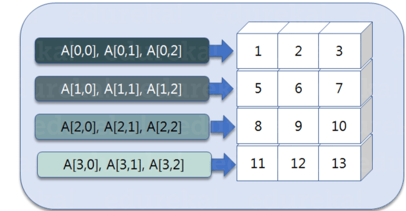

Here, I have different elements that are stored in their respective memory locations. It is said to be two dimensional because it has rows as well as columns. In the above image, we have 3 columns and 4 rows available.

### Single & Multi dimensional Numpy Array:

```python
import numpy as np
a=np.array([(11,22,33), (11,22,33)])
print(a)
```

```
[[11 22 33]
 [11 22 33]]
```

```python
#Multi-dimensional Array:
a=np.array([(1,2,3),(4,5,6)])
print(a)
type(a)
```

```
[[1 2 3]
 [4 5 6]]
```

```
numpy.ndarray
```

### Python NumPy Array v/s List

We use python numpy array instead of a list because of the below three reasons:

Less Memory

Fast

Convenient

The very first reason to choose python numpy array is that it occupies less memory as compared to list. Then, it is pretty fast in terms of execution and at the same time it is very convenient to work with numpy. So these are the major advantages that python numpy array has over list.

```python
#sys.getsizeof(S)
```

```python
import numpy as np

import time
import sys
S= range(1000)
# print(list(S))
print(sys.getsizeof(S))
print(sys.getsizeof(S)*len(S))

D= np.arange(1000)
print(D.itemsize)
print(D.size*D.itemsize)
# D
```

```
48
48000
4
4000
```

The above output shows that the memory allocated by list (denoted by S) is 48000 whereas the memory allocated by the numpy array is just 4000. From this, you can conclude that there is a major difference between the two and this makes python numpy array as the preferred choice over list.

```python
A1= np.arange(SIZE)
A1
```

[output not shown]

```python
#python numpy array is faster and more convenient when compared to list
# import time
# import sys

SIZE = 1000000

L1= range(SIZE)
L2= range(SIZE)
A1= np.arange(SIZE)
A2=np.arange(SIZE)

start= time.time()
print(start, "this is aa ")
result=[x+y for x,y in zip(L1,L2)]
print((time.time()-start)*1000)

start=time.time()
result= A1+A2
print((time.time()-start)*1000)
```

```
1591809159.311478 this is aa
92.58723258972168
15.951871871948242
```

```python
result
```

```python
list(zip(L1,L2))
```

[output not shown]

[output cut: 946 more lines]

[output not shown]